# STATS 506 Homework 4

Author

Yue He

Published

November 7, 2026

GitHub repository: https://github.com/heyuehul/506HW

## Attribution of sources

AI use: Claude helped me come up with ideas for the third question and assisted me in analyzing the code results. He also helped me write the code for the second question and debug the whole text.

Data sources: `nzge` from the nzelect package (Ellis, via its GitHub repository); 2019 ATP matches from the azhou5849/tennis-atp-sackmann-data repository; COVID-19 rolling averages from The New York Times covid-19-data repository.

```r
library(tidyverse)
library(knitr)
library(ggrepel)
```

## Problem 1 - Tidyverse: New Zealand

```r
# nzge.rds downloaded from the course site
nzge <- readRDS("nzge.rds") |>
  as_tibble()
glimpse(nzge)
```

```
Rows: 900,531
Columns: 10
$ approx_location   <chr> "Albury", "Arowhenua", "Burke Pass", "Cannington", "~
$ voting_place      <chr> "School", "Maori School, Huirapa Street", "Alpine Ca~
$ party             <chr> "ACT New Zealand", "ACT New Zealand", "ACT New Zeala~
$ votes             <dbl> 16, 4, 13, 6, 1, 16, 6, 17, 48, 14, 32, 47, 8, 7, 11~
$ electorate        <chr> "Aoraki", "Aoraki", "Aoraki", "Aoraki", "Aoraki", "A~
$ voting_type       <chr> "Party", "Party", "Party", "Party", "Party", "Party"~
$ candidate         <chr> NA, NA, NA, NA, NA, NA, NA, NA, NA, NA, NA, NA, NA, ~
$ election_year     <dbl> 2002, 2002, 2002, 2002, 2002, 2002, 2002, 2002, 2002~
$ electorate_number <dbl> 1, 1, 1, 1, 1, 1, 1, 1, 1, 1, 1, 1, 1, 1, 1, 1, 1, 1~
$ voting_place_id   <int> NA, NA, NA, NA, NA, NA, NA, NA, NA, NA, NA, NA, NA, ~
```

From `?nzge`, each row is the number of votes for one party (or the informal votes) at one voting place, for one vote type (`Candidate` = electorate vote, `Party` = list vote), in one election year. Because the two vote types are cast on the same ballot, they are always summarised separately below.

### a. Vote count per year and vote type

```r
nzge |>
  group_by(election_year, voting_type) |>
  summarise(total_votes = sum(votes), .groups = "drop") |>
  arrange(desc(total_votes)) |>
  mutate(election_year = as.character(election_year)) |>
  kable(col.names = c("Year", "Vote type", "Total votes"),
        format.args = list(big.mark = ","))
```

| Year | Vote type | Total votes |
| --- | --- | --- |
| 2017 | Party | 2,602,689 |
| 2017 | Candidate | 2,560,085 |
| 2014 | Party | 2,416,479 |
| 2014 | Candidate | 2,375,493 |
| 2008 | Party | 2,356,536 |
| 2008 | Candidate | 2,325,598 |
| 2005 | Party | 2,286,190 |
| 2005 | Candidate | 2,260,670 |
| 2011 | Party | 2,257,336 |
| 2011 | Candidate | 2,225,766 |
| 2002 | Party | 2,040,248 |
| 2002 | Candidate | 2,022,115 |

The totals include informal (invalid) votes, since the question asks for the count regardless of party. In every year the Party vote total is slightly larger than the Candidate vote total, and 2017 has the most votes of either type.

### b. 2014 Candidate election: proportion of votes by party

```r
nzge |>
  filter(election_year == 2014,
         voting_type == "Candidate",
         party != "Informal Candidate Votes") |>
  group_by(party) |>
  summarise(votes = sum(votes), .groups = "drop") |>
  mutate(percent = 100 * votes / sum(votes)) |>
  arrange(desc(percent)) |>
  kable(col.names = c("Party", "Votes", "Percent of valid votes"),
        digits = 2, format.args = list(big.mark = ","))
```

| Party | Votes | Percent of valid votes |
| --- | --- | --- |
| National Party | 1,081,787 | 46.08 |
| Labour Party | 801,287 | 34.13 |
| Green Party | 165,718 | 7.06 |
| Conservative Party | 81,075 | 3.45 |
| New Zealand First Party | 73,384 | 3.13 |
| Maori Party | 42,108 | 1.79 |
| MANA Movement | 32,333 | 1.38 |
| ACT New Zealand | 27,778 | 1.18 |
| United Future | 14,722 | 0.63 |
| Aotearoa Legalise Cannabis Party | 4,936 | 0.21 |
| Internet Party | 4,848 | 0.21 |
| Democrats for Social Credit | 4,647 | 0.20 |
| Ban1080 | 4,448 | 0.19 |
| Independent | 3,864 | 0.16 |
| NZ Independent Coalition | 1,929 | 0.08 |
| Focus New Zealand | 1,797 | 0.08 |
| Money Free Party | 391 | 0.02 |
| Communist League | 135 | 0.01 |
| Climate Party | 116 | 0.00 |
| Human Rights Party | 76 | 0.00 |
| The Expats | 70 | 0.00 |
| Alliance | 59 | 0.00 |
| NZ Economic Euthenics Party | 51 | 0.00 |
| Patriotic Revolutionary Front | 48 | 0.00 |

### c. Winning party by year and vote type

```r
nzge |>
  filter(!str_detect(party, "^Informal")) |>
  group_by(election_year, voting_type, party) |>
  summarise(votes = sum(votes), .groups = "drop_last") |>
  slice_max(votes, n = 1) |>
  ungroup() |>
  select(election_year, voting_type, party) |>
  pivot_wider(names_from = voting_type, values_from = party) |>
  kable(col.names = c("Year", "Candidate vote winner", "Party vote winner"))
```

| Year | Candidate vote winner | Party vote winner |
| --- | --- | --- |
| 2002 | Labour Party | Labour Party |
| 2005 | National Party | Labour Party |
| 2008 | National Party | National Party |
| 2011 | National Party | National Party |
| 2014 | National Party | National Party |
| 2017 | National Party | National Party |

Labour won both votes in 2002. In 2005 the votes split: National narrowly won the Candidate vote (by about 800 votes nationally) while Labour won the Party vote, which is what determines seat allocation under MMP. From 2008 to 2017 the National Party won both votes.

## Problem 2 - Tidyverse: Tennis

```r
atp_url <- paste0("https://raw.githubusercontent.com/azhou5849/",
                  "tennis-atp-sackmann-data/master/atp_matches_2019.csv")
atp <- read_csv(atp_url, show_col_types = FALSE)
dim(atp)
```

```
[1] 2806   49
```

Each row is one match. Exploring the identifying columns:

```r
atp |>
  distinct(tourney_id, tourney_name, tourney_level) |>
  count(tourney_level, name = "n_tourney_ids")
```

```
# A tibble: 5 x 2
  tourney_level n_tourney_ids
  <chr>                 <int>
1 A                        53
2 D                        60
3 F                         2
4 G                         4
5 M                         9
```

```r
atp |>
  count(round)
```

```
# A tibble: 8 x 2
  round     n
  <chr> <int>
1 F        67
2 QF      260
3 R128    320
4 R16     520
5 R32     900
6 R64     400
7 RR      205
8 SF      134
```

```r
atp |>
  filter(tourney_level == "D") |>
  distinct(tourney_name) |>
  slice_head(n = 5)
```

```
# A tibble: 5 x 1
  tourney_name
  <chr>
1 Davis Cup Finals RR: FRA vs JPN
2 Davis Cup Finals RR: FRA vs SRB
3 Davis Cup Finals RR: SRB vs JPN
4 Davis Cup Finals RR: CRO vs ESP
5 Davis Cup Finals RR: CRO vs RUS
```

`tourney_level` codes are A (ATP 250/500), M (Masters 1000), G (Grand Slams), F (season finals) and D (Davis Cup). Every Davis Cup *tie* (one country vs. another) gets its own `tourney_id`, so the 60 Davis Cup IDs are rubbers of a single team competition, not separate tournaments. The Laver Cup is also a team exhibition and has no final.

### a. Number of tournaments in 2019

```r
atp |>
  summarise(
    all_tourney_ids         = n_distinct(tourney_id),
    davis_cup_ties          = n_distinct(tourney_id[tourney_level == "D"]),
    individual_tournaments  = n_distinct(tourney_id[tourney_level != "D" &
                                                    tourney_name != "Laver Cup"])
  ) |>
  kable(col.names = c("All tourney IDs", "Davis Cup ties",
                      "Individual tournaments"))
```

| All tourney IDs | Davis Cup ties | Individual tournaments |
| --- | --- | --- |
| 128 | 60 | 67 |

There are 128 distinct `tourney_id`s, but 60 are Davis Cup ties and one is the Laver Cup. Counting individual tournaments that crown a champion, **67 tournaments** took place in 2019 (68 if the Laver Cup is counted as one event, 69 if the Davis Cup is also counted as a single tournament).

### b. Players who won more than one tournament

A tournament’s winner is the winner of its final (`round == "F"`).

```r
titles <- atp |>
  filter(round == "F") |>
  count(winner_name, name = "titles", sort = TRUE)

titles |>
  filter(titles > 1) |>
  kable(col.names = c("Player", "Titles"))
```

| Player | Titles |
| --- | --- |
| Dominic Thiem | 5 |
| Novak Djokovic | 5 |
| Daniil Medvedev | 4 |
| Rafael Nadal | 4 |
| Roger Federer | 4 |
| Alex De Minaur | 3 |
| Stefanos Tsitsipas | 3 |
| Benoit Paire | 2 |
| Cristian Garin | 2 |
| Jo-Wilfried Tsonga | 2 |
| Matteo Berrettini | 2 |
| Nick Kyrgios | 2 |

```r
titles |>
  summarise(players_with_multiple_titles = sum(titles > 1),
            max_titles = max(titles))
```

```
# A tibble: 1 x 2
  players_with_multiple_titles max_titles
                         <int>      <int>
1                           12          5
```

Yes. 12 players won more than one tournament. The top winners, Dominic Thiem and Novak Djokovic, each won 5 tournaments (the table above lists everyone with 2 or more).

### c. Do winners hit more aces than losers?

Each match gives a natural pair (winner’s aces, loser’s aces), so a paired t-test on the per-match difference is appropriate. The test is computed by hand inside a dplyr pipeline.

```r
atp |>
  filter(!is.na(w_ace), !is.na(l_ace)) |>
  mutate(ace_diff = w_ace - l_ace) |>
  summarise(
    n_matches       = n(),
    mean_w_ace      = mean(w_ace),
    mean_l_ace      = mean(l_ace),
    mean_diff       = mean(ace_diff),
    se_diff         = sd(ace_diff) / sqrt(n_matches),
    t_stat          = mean_diff / se_diff,
    p_value_one_sid = pt(t_stat, df = n_matches - 1, lower.tail = FALSE)
  ) |>
  kable(digits = 4)
```

| n_matches | mean_w_ace | mean_l_ace | mean_diff | se_diff | t_stat | p_value_one_sid |
| --- | --- | --- | --- | --- | --- | --- |
| 2694 | 7.4974 | 5.7925 | 1.7049 | 0.1378 | 12.373 | 0 |

Over the 2,694 matches with ace data, winners averaged 7.5 aces and losers 5.8, a mean difference of about 1.7 aces per match. The one-sided paired test (H0: mean difference = 0, H1: winners hit more aces) gives t = 12.4 on 2,693 degrees of freedom and a p-value of about 1.5e-34, so there is strong evidence that match winners hit more aces than losers. (This is an association; serving well both produces aces and wins matches.)

### d. Highest win rate (at least 5 matches)

```r
atp |>
  select(winner_name, loser_name) |>
  pivot_longer(everything(), names_to = "result", values_to = "player") |>
  group_by(player) |>
  summarise(matches  = n(),
            wins     = sum(result == "winner_name"),
            win_rate = wins / matches,
            .groups  = "drop") |>
  filter(matches >= 5) |>
  slice_max(win_rate, n = 5) |>
  kable(col.names = c("Player", "Matches", "Wins", "Win rate"), digits = 3)
```

| Player | Matches | Wins | Win rate |
| --- | --- | --- | --- |
| Rafael Nadal | 69 | 60 | 0.870 |
| Novak Djokovic | 69 | 58 | 0.841 |
| Roger Federer | 66 | 55 | 0.833 |
| Daniil Medvedev | 80 | 59 | 0.738 |
| Kevin Anderson | 15 | 11 | 0.733 |

Among players with at least 5 matches, **Rafael Nadal** has the highest win rate: 60 wins in 69 matches (87.0%), ahead of Djokovic (84.1%) and Federer (83.3%). All matches in the file are counted, including Davis Cup rubbers and walkovers.

## Problem 3 - Visualization

```r
covid_url <- paste0("https://raw.githubusercontent.com/nytimes/covid-19-data/",
                    "refs/heads/master/rolling-averages/us-states.csv")
territories <- c("Puerto Rico", "Guam", "Virgin Islands",
                 "Northern Mariana Islands", "American Samoa")
covid <- read_csv(covid_url, show_col_types = FALSE) |>
  filter(!state %in% territories)   # 50 states + DC
range(covid$date)
```

```
[1] "2020-01-21" "2023-03-23"
```

`cases_avg` is the 7-day rolling average of new cases and `cases_avg_per_100k` is the same quantity per 100,000 residents, so it is already adjusted for population.

### a. Major and minor spikes

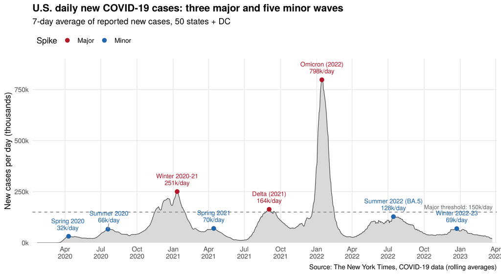

```r
national <- covid |>
  group_by(date) |>
  summarise(cases_avg = sum(cases_avg, na.rm = TRUE), .groups = "drop")

# label the highest point inside each wave's window
waves <- tribble(
  ~wave,                   ~start,       ~end,         ~type,
  "Spring 2020",           "2020-03-01", "2020-05-31", "Minor",
  "Summer 2020",           "2020-06-01", "2020-09-15", "Minor",
  "Winter 2020-21",        "2020-10-01", "2021-03-01", "Major",
  "Spring 2021",           "2021-03-01", "2021-06-01", "Minor",
  "Delta (2021)",          "2021-07-01", "2021-11-01", "Major",
  "Omicron (2022)",        "2021-12-01", "2022-03-01", "Major",
  "Summer 2022 (BA.5)",    "2022-05-01", "2022-09-30", "Minor",
  "Winter 2022-23",        "2022-11-01", "2023-02-01", "Minor"
) |>
  mutate(across(c(start, end), as.Date))

peaks <- waves |>
  rowwise() |>
  mutate(peak = list(national |>
                       filter(date >= start, date < end) |>
                       slice_max(cases_avg, n = 1, with_ties = FALSE))) |>
  ungroup() |>
  unnest(peak)

ggplot(national, aes(date, cases_avg / 1000)) +
  geom_area(fill = "grey85") +
  geom_line(colour = "grey30", linewidth = 0.4) +
  geom_hline(yintercept = 150, linetype = "dashed", colour = "grey50") +
  geom_point(data = peaks, aes(colour = type), size = 2.5) +
  geom_text_repel(data = peaks,
                  aes(label = paste0(wave, "\n",
                                     scales::comma(round(cases_avg / 1000)),
                                     "k/day"),
                      colour = type),
                  size = 3.2, nudge_y = 60, segment.colour = "grey60",
                  lineheight = 0.9, show.legend = FALSE) +
  annotate("text", x = as.Date("2022-10-01"), y = 175,
           label = "Major threshold: 150k/day", hjust = 0, size = 3,
           colour = "grey40") +
  scale_colour_manual(values = c(Major = "#B2182B", Minor = "#2166AC"),
                      name = "Spike") +
  scale_x_date(date_breaks = "3 months", date_labels = "%b\n%Y",
               expand = expansion(mult = 0.01)) +
  scale_y_continuous(labels = scales::label_comma(suffix = "k"),
                     expand = expansion(mult = c(0, 0.05))) +
  labs(title = "U.S. daily new COVID-19 cases: three major and five minor waves",
       subtitle = "7-day average of reported new cases, 50 states + DC",
       x = NULL, y = "New cases per day (thousands)",
       caption = "Source: The New York Times, COVID-19 data (rolling averages)") +
  theme_minimal(base_size = 12) +
  theme(panel.grid.minor = element_blank(),
        legend.position = "top", legend.justification = "left",
        plot.title = element_text(face = "bold"))
```

I count **8 spikes: 3 major and 5 minor**. I define a major spike as a wave whose national 7-day average exceeded 150,000 cases/day (dashed line): winter 2020-21, the Delta wave (late summer 2021), and the Omicron wave (January 2022, peaking around 800k/day, more than three times any other wave). The minor spikes are spring 2020, summer 2020, spring 2021, summer 2022 (BA.5) and winter 2022-23. Waves after early 2022 are likely understated because home testing meant many cases were never reported.

### b. Highest vs. lowest overall rates

The overall rate per population is the total reported cases per 100,000 residents. Summing the daily 7-day average per 100k over the whole period gives that cumulative rate.

```r
state_rates <- covid |>
  group_by(state) |>
  summarise(total_per_100k = sum(cases_avg_per_100k, na.rm = TRUE),
            .groups = "drop") |>
  arrange(desc(total_per_100k))

extremes <- bind_rows(
  slice_head(state_rates, n = 5) |> mutate(group = "Highest 5 states"),
  slice_tail(state_rates, n = 5) |> mutate(group = "Lowest 5 states")
)
extremes |>
  kable(col.names = c("State", "Total cases per 100k", "Group"),
        digits = 0, format.args = list(big.mark = ","))
```

| State | Total cases per 100k | Group |
| --- | --- | --- |
| Rhode Island | 43,296 | Highest 5 states |
| Alaska | 41,835 | Highest 5 states |
| Kentucky | 39,042 | Highest 5 states |
| North Dakota | 37,604 | Highest 5 states |
| Tennessee | 36,181 | Highest 5 states |
| District of Columbia | 25,344 | Lowest 5 states |
| Vermont | 24,518 | Lowest 5 states |
| Oregon | 22,915 | Lowest 5 states |
| Maryland | 22,091 | Lowest 5 states |
| Maine | 22,020 | Lowest 5 states |

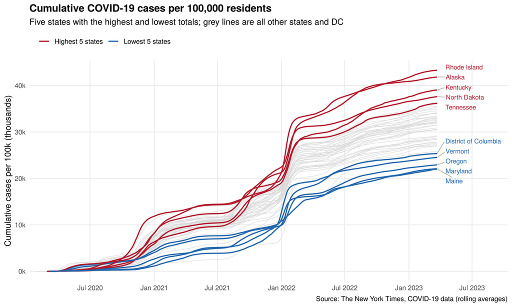

```r
cum <- covid |>
  arrange(state, date) |>
  group_by(state) |>
  mutate(cum_per_100k = cumsum(replace_na(cases_avg_per_100k, 0))) |>
  ungroup()

cum_ext <- cum |>
  inner_join(extremes |> select(state, group), by = "state")

end_labels <- cum_ext |>
  filter(date == max(date))

ggplot(cum, aes(date, cum_per_100k / 1000, group = state)) +
  geom_line(colour = "grey85", linewidth = 0.3) +
  geom_line(data = cum_ext, aes(colour = group), linewidth = 0.8) +
  geom_text_repel(data = end_labels,
                  aes(label = state, colour = group),
                  direction = "y", hjust = 0, nudge_x = 25, size = 3.2,
                  segment.colour = "grey70", show.legend = FALSE) +
  scale_colour_manual(values = c("Highest 5 states" = "#B2182B",
                                 "Lowest 5 states" = "#2166AC"),
                      name = NULL) +
  scale_x_date(date_breaks = "6 months", date_labels = "%b %Y",
               expand = expansion(mult = c(0.01, 0.15))) +
  scale_y_continuous(labels = scales::label_comma(suffix = "k")) +
  labs(title = "Cumulative COVID-19 cases per 100,000 residents",
       subtitle = paste("Five states with the highest and lowest totals;",
                        "grey lines are all other states and DC"),
       x = NULL, y = "Cumulative cases per 100k (thousands)",
       caption = "Source: The New York Times, COVID-19 data (rolling averages)") +
  theme_minimal(base_size = 12) +
  theme(panel.grid.minor = element_blank(),
        legend.position = "top", legend.justification = "left",
        plot.title = element_text(face = "bold"))
```

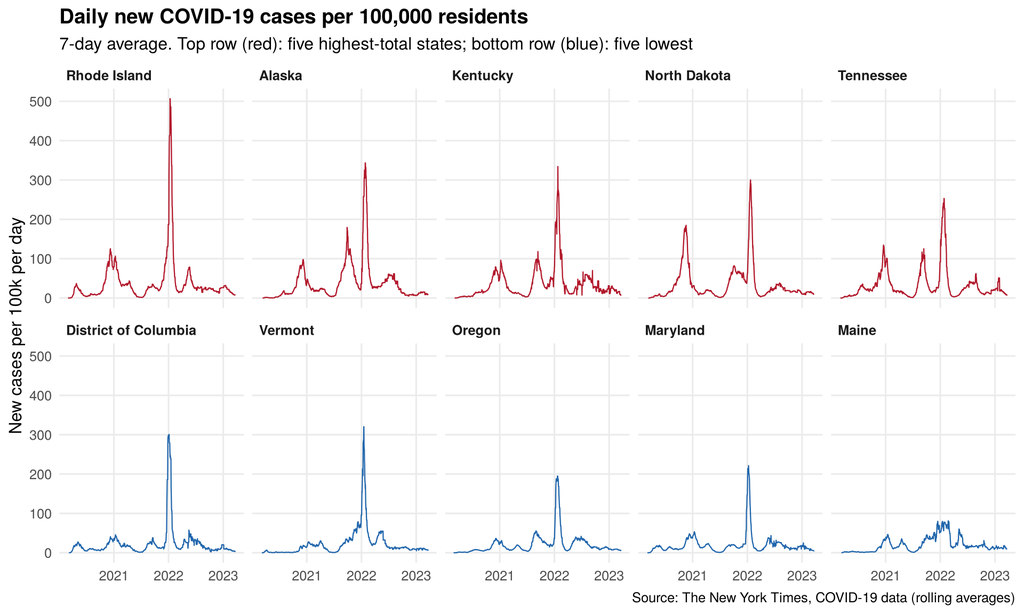

```r
covid |>
  inner_join(extremes |> select(state, group), by = "state") |>
  mutate(state = factor(state, levels = extremes$state)) |>
  ggplot(aes(date, cases_avg_per_100k, colour = group)) +
  geom_line(linewidth = 0.4, show.legend = FALSE) +
  facet_wrap(~ state, nrow = 2) +
  scale_x_date(date_breaks = "1 year", date_labels = "%Y") +
  scale_colour_manual(values = c("Highest 5 states" = "#B2182B",
                                 "Lowest 5 states" = "#2166AC")) +
  labs(title = "Daily new COVID-19 cases per 100,000 residents",
       subtitle = paste("7-day average. Top row (red): five highest-total states;",
                        "bottom row (blue): five lowest"),
       x = NULL, y = "New cases per 100k per day",
       caption = "Source: The New York Times, COVID-19 data (rolling averages)") +
  theme_minimal(base_size = 12) +
  theme(panel.grid.minor = element_blank(),
        strip.text = element_text(face = "bold", hjust = 0),
        plot.title = element_text(face = "bold"))
```

The highest-rate states are Rhode Island, Alaska, Kentucky, North Dakota and Tennessee; the lowest are Maine, Maryland, Oregon, Vermont and DC.

So the difference between the groups was built up mostly in the 2020-21 winter and Delta waves, not in Omicron, when the whole country was hit at once.

### c. First five states to experience COVID-19 substantially

I define “substantial” as the 7-day average first reaching 5 new cases per 100,000 residents per day, which puts states of different sizes on the same footing.

```r
threshold <- 5

first_dates <- covid |>
  filter(cases_avg_per_100k >= threshold) |>
  group_by(state) |>
  summarise(first_date = min(date), .groups = "drop") |>
  arrange(first_date)

first_five <- first_dates |> slice_head(n = 5)
first_five |>
  kable(col.names = c("State", paste("First day with >=", threshold,
                                     "cases per 100k")))
```

| State | First day with >= 5 cases per 100k |
| --- | --- |
| New York | 2020-03-21 |
| New Jersey | 2020-03-24 |
| Louisiana | 2020-03-26 |
| Massachusetts | 2020-03-27 |
| Connecticut | 2020-03-28 |

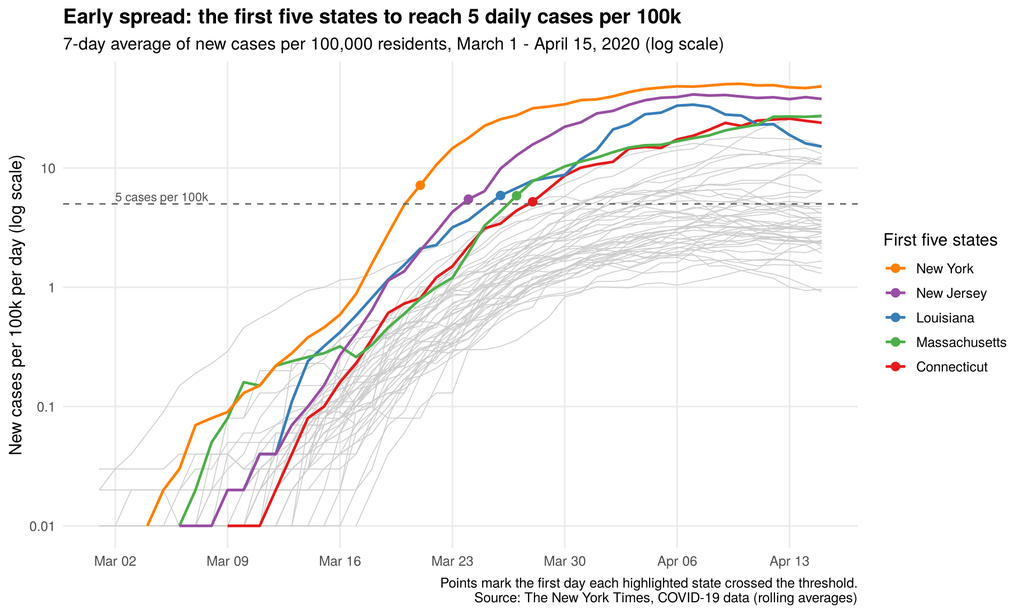

```r
early <- covid |>
  filter(date >= as.Date("2020-03-01"), date <= as.Date("2020-04-15"),
         cases_avg_per_100k > 0) |>   # log scale cannot show zeros
  mutate(highlight = if_else(state %in% first_five$state, state, "Other"))

ggplot(early, aes(date, cases_avg_per_100k, group = state)) +
  geom_line(data = filter(early, highlight == "Other"),
            colour = "grey80", linewidth = 0.3) +
  geom_line(data = filter(early, highlight != "Other"),
            aes(colour = highlight), linewidth = 0.9) +
  geom_hline(yintercept = threshold, linetype = "dashed", colour = "grey40") +
  geom_point(data = first_five |>
               left_join(covid, by = c("state", "first_date" = "date")),
             aes(first_date, cases_avg_per_100k, colour = state),
             inherit.aes = FALSE, size = 2.5) +
  annotate("text", x = as.Date("2020-03-02"), y = threshold * 1.15,
           label = "5 cases per 100k", hjust = 0, size = 3, colour = "grey30") +
  scale_y_log10(breaks = c(0.01, 0.1, 1, 10, 100),
                labels = c("0.01", "0.1", "1", "10", "100")) +
  scale_x_date(date_breaks = "1 week", date_labels = "%b %d") +
  scale_colour_brewer(palette = "Set1", name = "First five states",
                      breaks = first_five$state) +
  labs(title = "Early spread: the first five states to reach 5 daily cases per 100k",
       subtitle = "7-day average of new cases per 100,000 residents, March 1 - April 15, 2020 (log scale)",
       x = NULL, y = "New cases per 100k per day (log scale)",
       caption = "Points mark the first day each highlighted state crossed the threshold.\nSource: The New York Times, COVID-19 data (rolling averages)") +
  theme_minimal(base_size = 12) +
  theme(panel.grid.minor = element_blank(),
        plot.title = element_text(face = "bold"))
```

By this measure the first five states were **New York, New Jersey, Louisiana, Massachusetts and Connecticut**, all crossing the threshold between March 21 and March 28, 2020. The answer is fairly robust: with a 10 per 100k threshold the same states plus Michigan lead the list, though at a looser 1 per 100k threshold Washington (the first reported U.S. case, January 2020) moves to the front.